# An Exploration of School Performance

Michael Brakenhoff

## Introduction

### A. Purpose

It is important for schools to meet the needs of all students equally. The purpose of this study is visualize performance of commonly marginalized demographics to ensure the school is performing in line with this standard. Further, it has been hypothesized that some of the primary schools in the district are hindering performance. Finally, in the event of an educational discrepancy, it is desired to identify students in need of further supports early in their high school career. It is proposed that performance on standardized test taken at the beginning of Freshman year can be used to identify these students.

### B. Aims

1. Data visualization will be used to explore the data for any inconsistencies or patterns indicating a lack of equal opportunity for all children in the high school. In particular inequality based upon ethnicity, gender, or special needs.
2. Primary schools will be explored to determine if any inequalities in GPA and state assessment performance.
3. Relationship between GPA and Standardized test scores will be explored to determine correlation could be used to identify students in need of support.

### C. Summary

Exploration of the data indicated three areas of concern. Fist, there appears to be an under performance by males particularly from specific primary schools. Second, an overall under performance by black students, particularly those that transfer to the district after primary school. Last, also within students that transfer to the district, students with a Hispanic ethnicity under perform in GPA.  
Visual examination indicates that correlation between GPA and standardized assessments could be used to identify students in need of extra support.

## Data Sources

All data was collected from students at a high school of interest over a 3 year span (2015-2018). They were selected by enrolling in a specific, required Geometry class (first semester).

### Data Description

Included in the data set for each selected student is their GPA at the completion of their Geometry class (**GPA**), the elementary school they attended (**School**), if they had ever been flagged for special services- English language learner, behavior plan, or 504 (**Flag**)-, the students gender (**Sex**), and the students race (**Race**). Each individuals students performance on the ACT Aspire, taken during their $9^{th}$ grade year, is also recorded. Performance in **English**, **Math**, **Reading**, and **Science** are assessed (scaled 400 to 460).  
“School” is coded to correspond to the elementary schools within the school district (1-4), with “5” corresponding to those individuals that transferred to the district after elementary school. If an individual attended multiple elementary schools the one most attended during the primary years was chosen.  
“Flag” is coded: 1 if “yes”, 0 if “no.” To preserve privacy students will be designated with a random ID number (**ID**).

- GPA is a continous variable with no missing values.
- School is a nominal variable with no missing values.
- English, Math, Reading, and Science are continuous variables. English has 7 missing values, Math and Reading has 19 missing values, and Science has 18 missing values.
- Flag is a nominal dummy variable with no missing values.
- Sex is a nominal variable with no missing values.
- Race is a nominal variable with no missing values.

## Visual Analysis

### Black Inequallity

A plot of GPA by average standardized assessment score appears to highlight some potential issues with ethnicity. Black students cluster on the left side, indicating poor performance on standardized test.

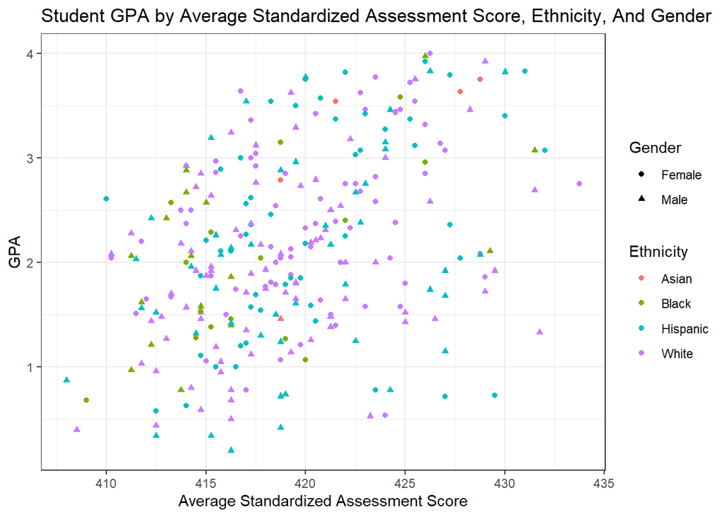

Looking at scores across assessment topics, there is a strong clustering below a score of 420 in Math, Science, and Reading. Within this range there is a wide range in GPA. This indicates a lack of preparedness for the standardized test for black students.

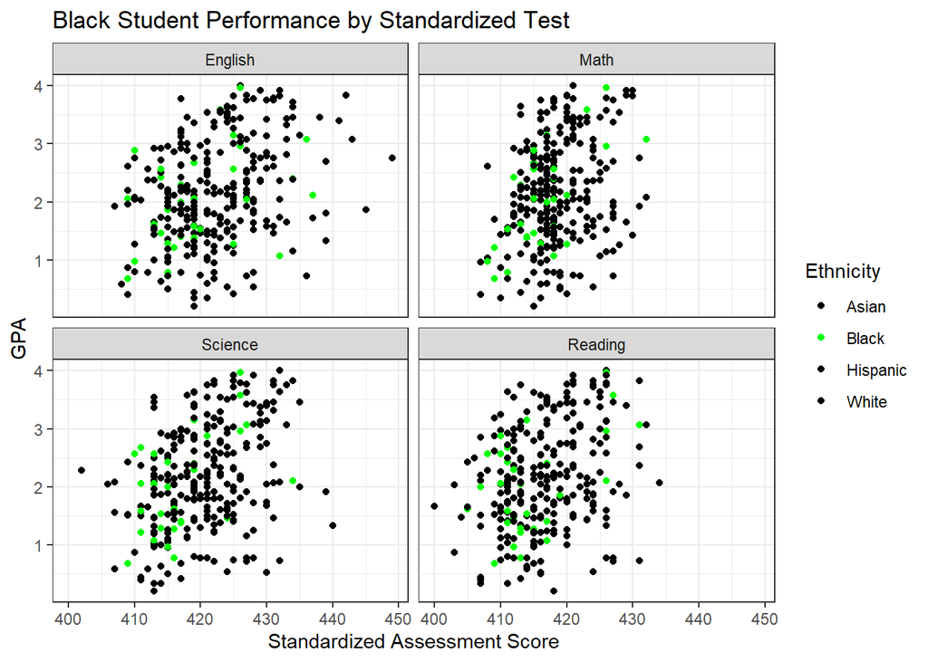

Looking at scores across primary schools shows that only 1 student that attended primary school in district average a score over 420. Exceptionallities do not appear to have any influence on this pattern.

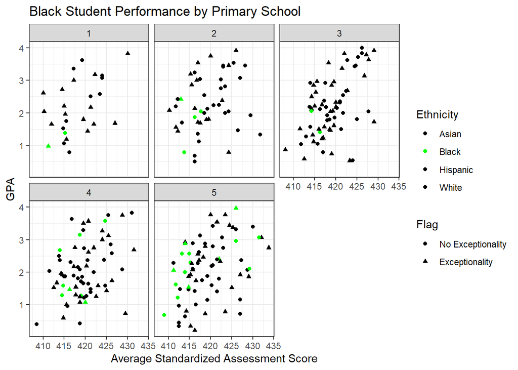

### Hispanic Transfer Inequallity

Examining performance across schools by ethnicity identifies another potential issue. School 5 - student that transfer to the district after Primary School- has a low GPA for hispanic students. Average standardized test scores have a wide spread while GPA remains low for a concentration of several hispanic students. Many of the hispanic students score as expect but there is a high concentration with a low GPA. Exceptionallities do not appear to have any influence on this pattern.

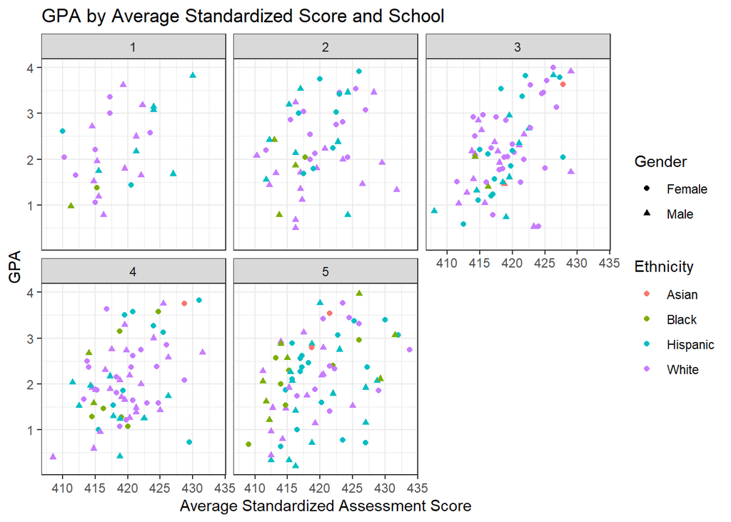

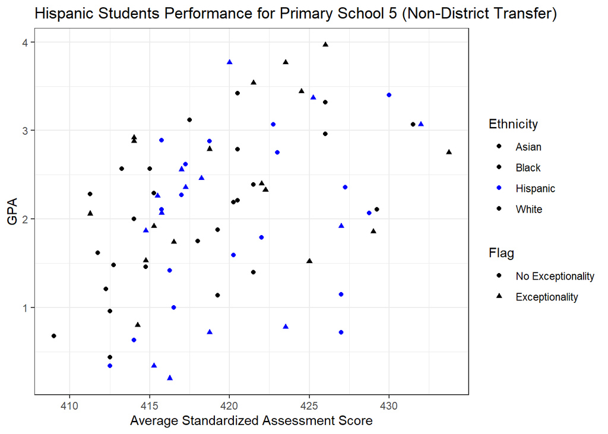

### Primary School Issues

Examining performance across school indicates an issue with primary school 2. There is a high concentration of low GPA for Males but a wide range of Average Standardized Assessment scores for the same observations. Neither exceptionallities nor ethnicity appear to have any influence on this pattern.

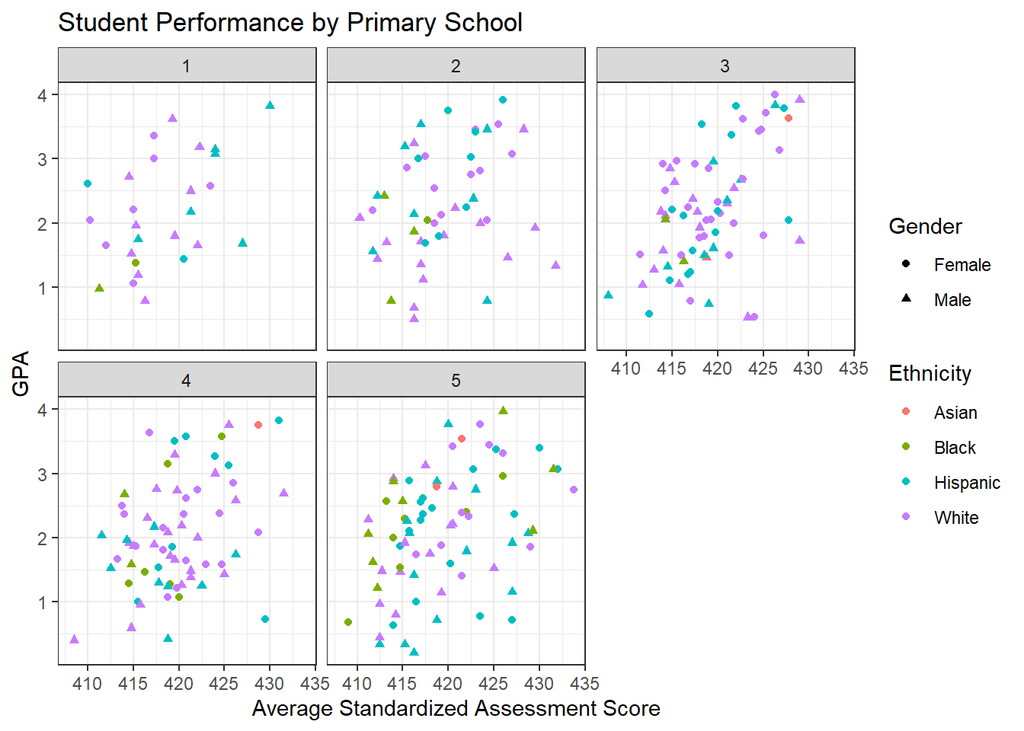

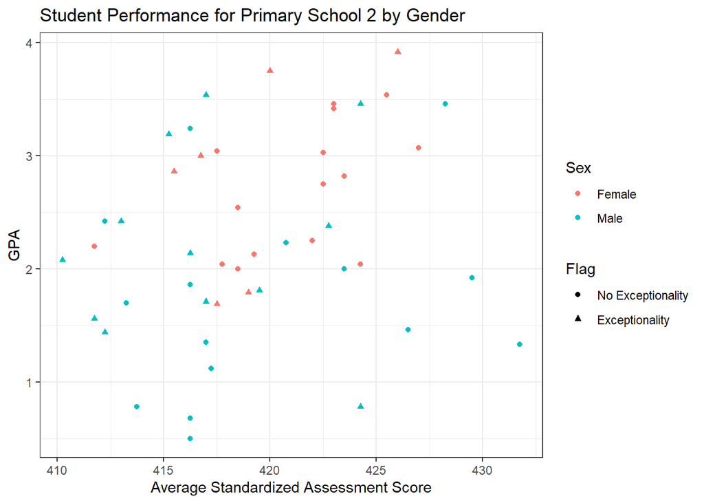

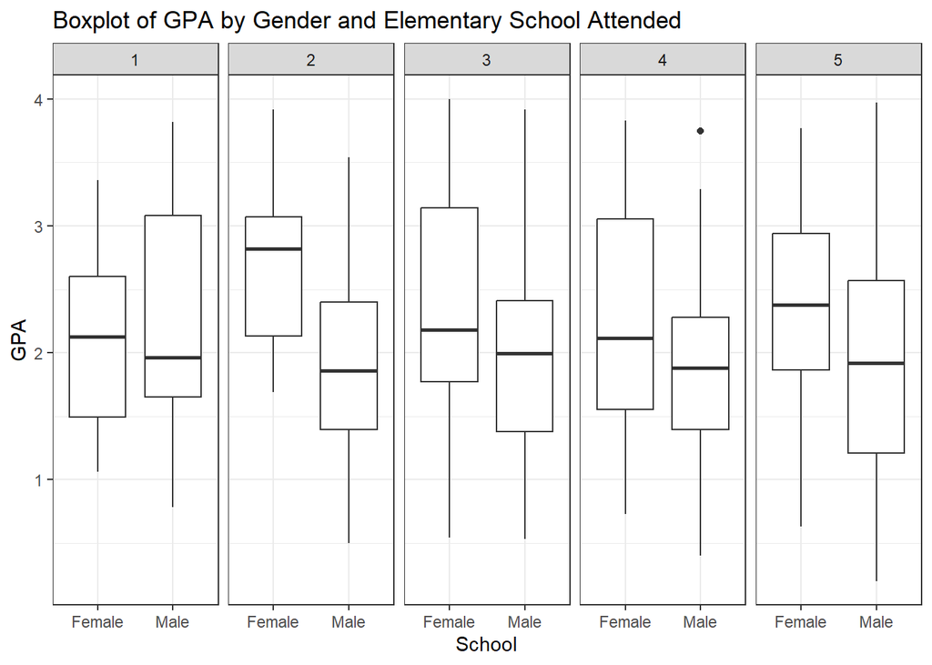

### Exceptionallities

Examining performance across primary schools by exceptionallities show no issues.

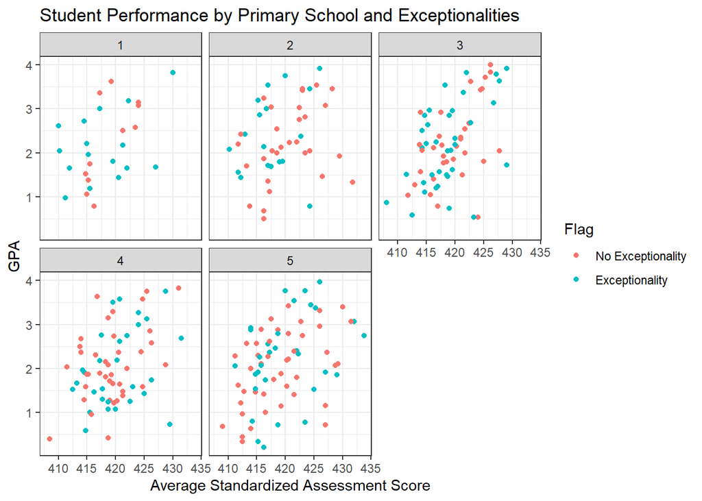

### Predicting GPA

There appears to be be a strong correlation between standardized test scores and GPA which could be used to predict GPA. Plotting GPA by standardized test indicates that each assessment would produce similar results (none have a larger effect than the other), so the average score will be used. Controlling for exceptionallities, gender, ethnicity and school indicates there is no significant change in the prediction line outside of primary school attended. Ethnicity is sparse for several levels so more data should be collected to properly determine influence.

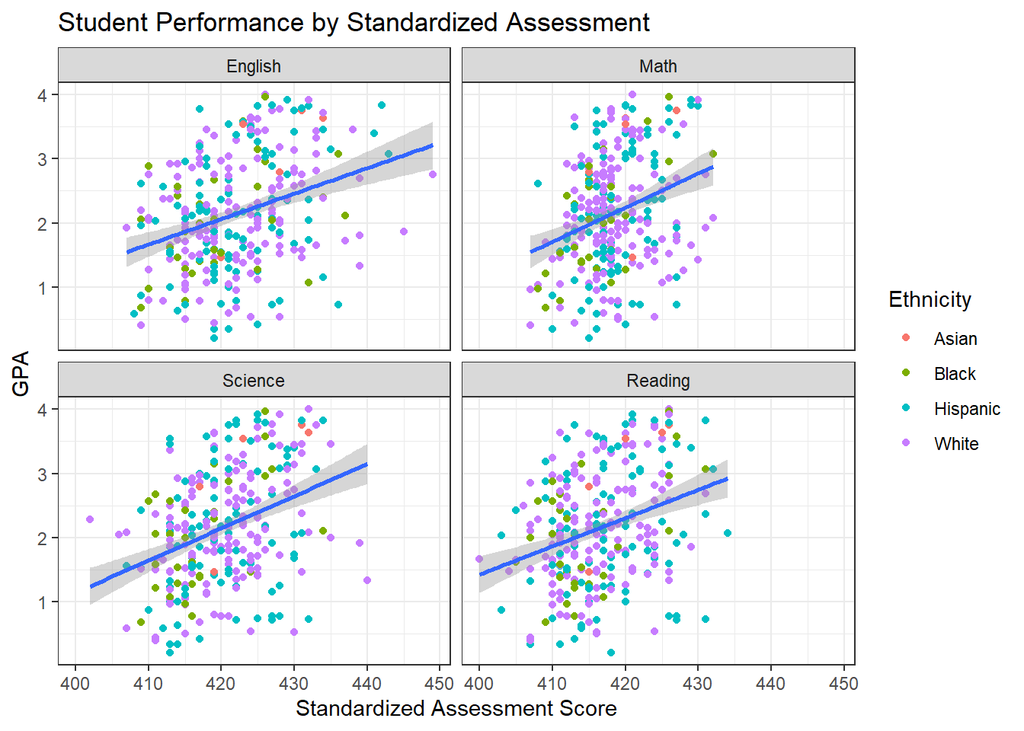

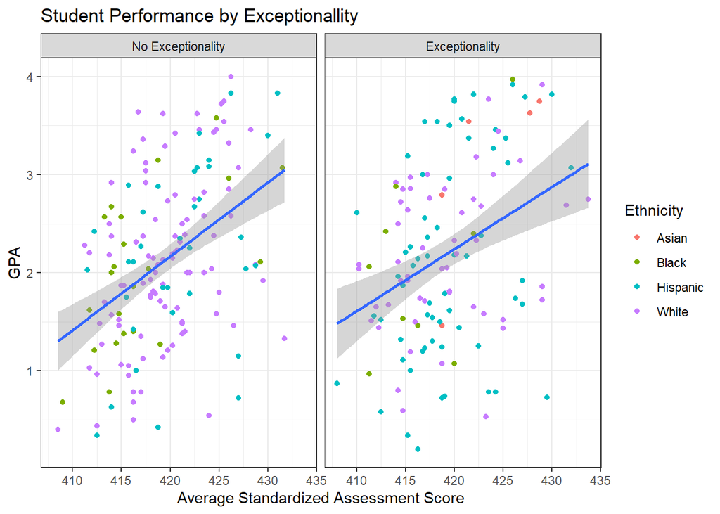

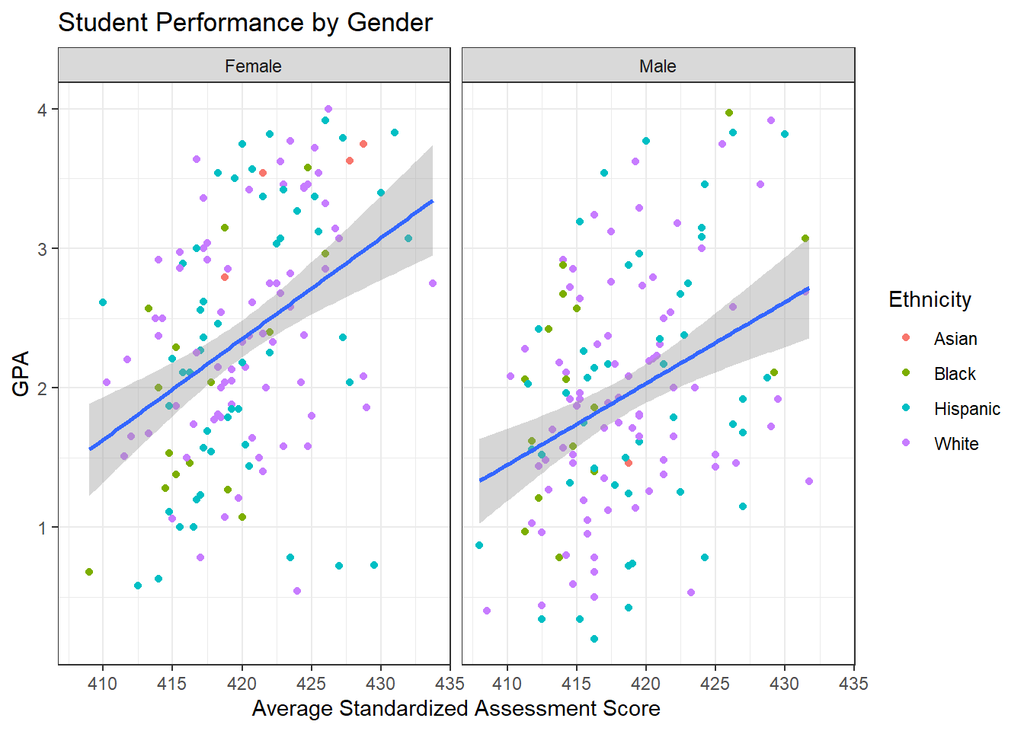

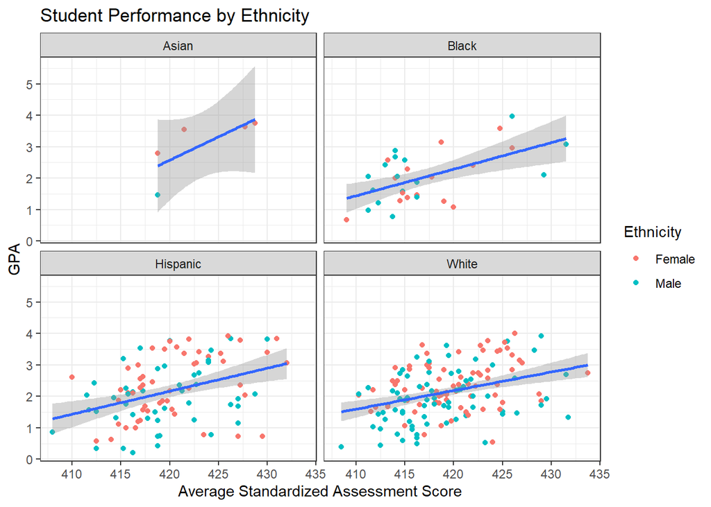

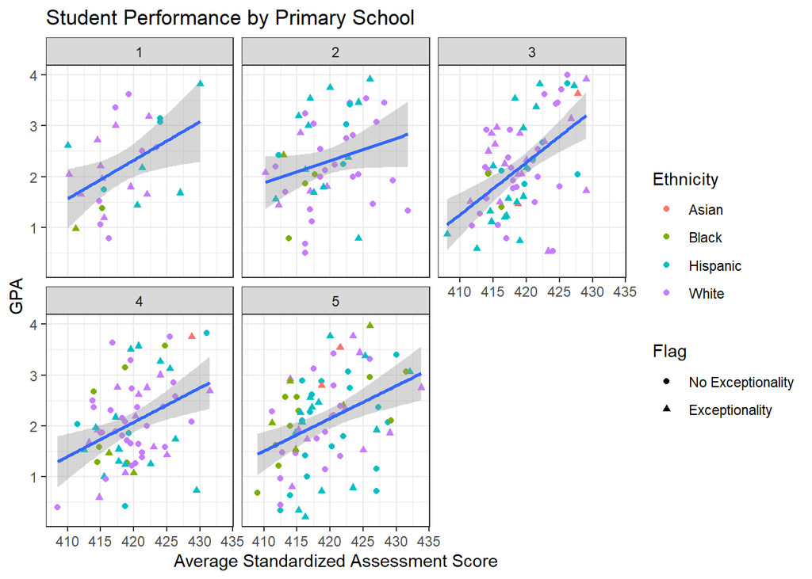

## Conclusions

There is a clear issue with black students performance on standardized assessments. It is clear that the issue lies in the district due to many students that transferred into district after primary school performed much better while only one from within the district performed above the 420 threshold. Further information, such as socio-economic status should be collected to identify the cause of this issue.  
The issue with low performing Hispanic transfers may be an anomaly. Considering the district has a large immigrant population it is possible that these students are unidentified ELL or ESL students.  
The discrepancy in GPA based on gender for students that attended primary school “2” appears to be a clear issue. Again, there are many factors that could be at play to cause this issue but given it is based upon a specific region it is likely to be caused by other environmental factors. Based on the collection of scatter plots there is a clear correlation between standardized test and GPA, with the primary school attended being the most influential. There appears to be predictive power but further analysis should be performed to determine what variables would be most useful in building a predictive model.

## Appendix

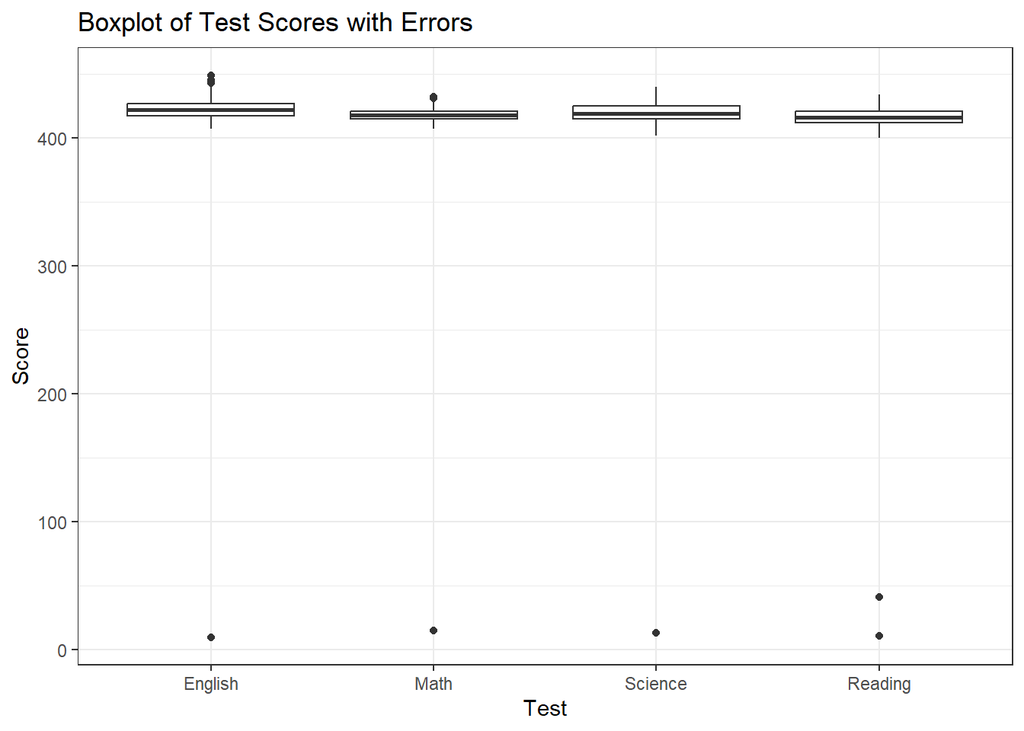

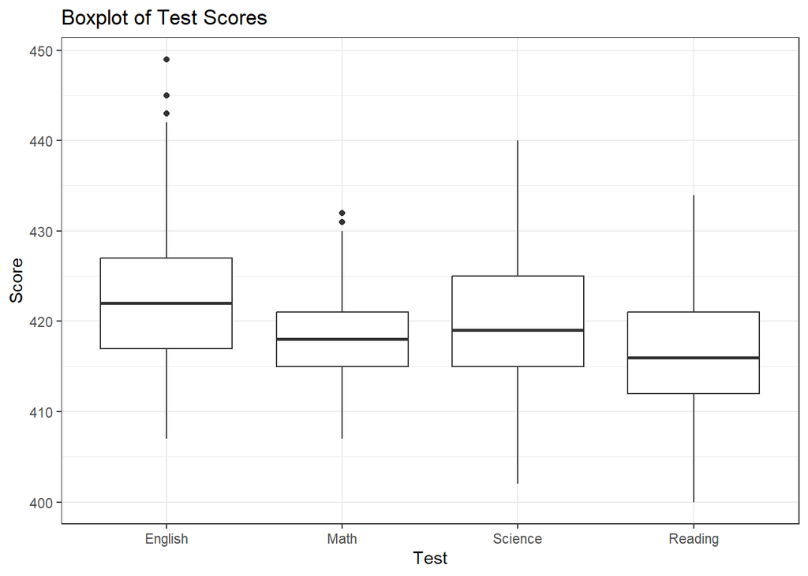

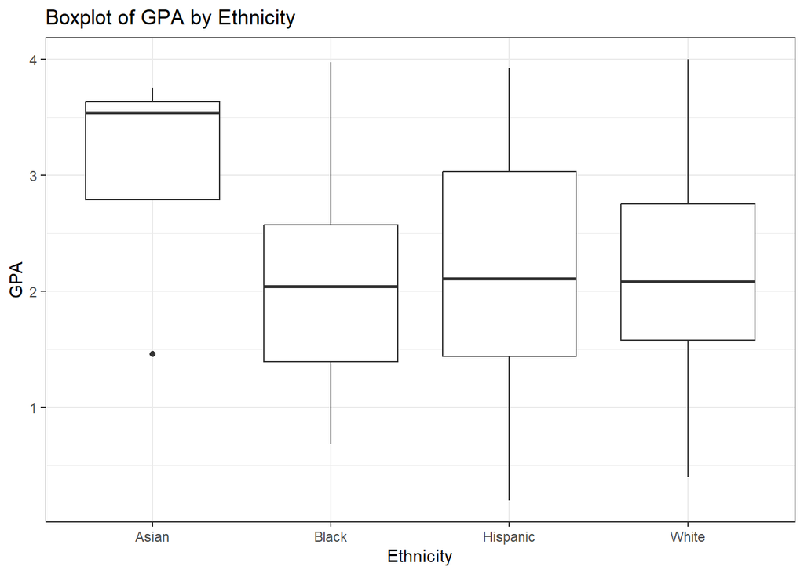

| Ethnicity | Count |
| --- | --- |
| Asian | 5 |
| Black | 31 |
| Hispanic | 97 |
| White | 154 |

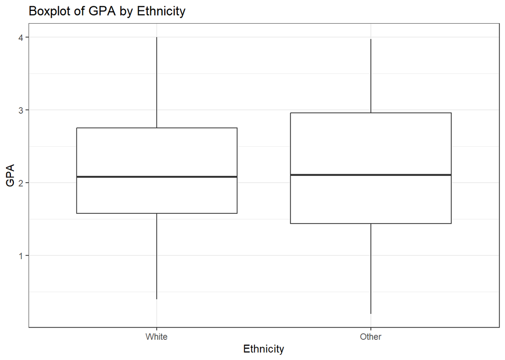

| Ethnicity | Count |
| --- | --- |
| White | 154 |
| Other | 133 |

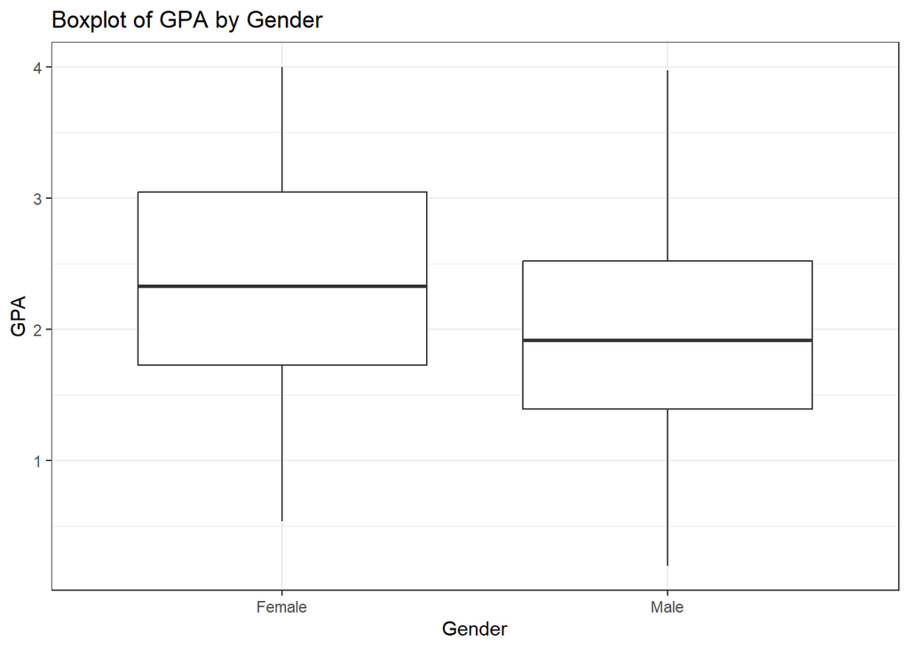

| Sex | Count |
| --- | --- |
| Female | 144 |
| Male | 143 |

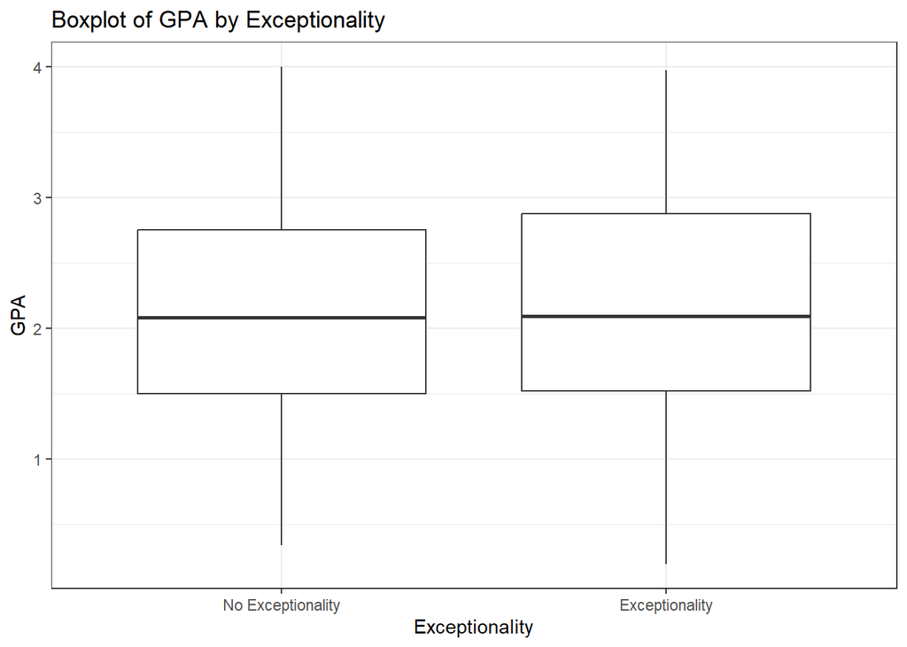

| Flagged for Services | Count |
| --- | --- |
| No Exceptionality | 157 |
| Exceptionality | 130 |

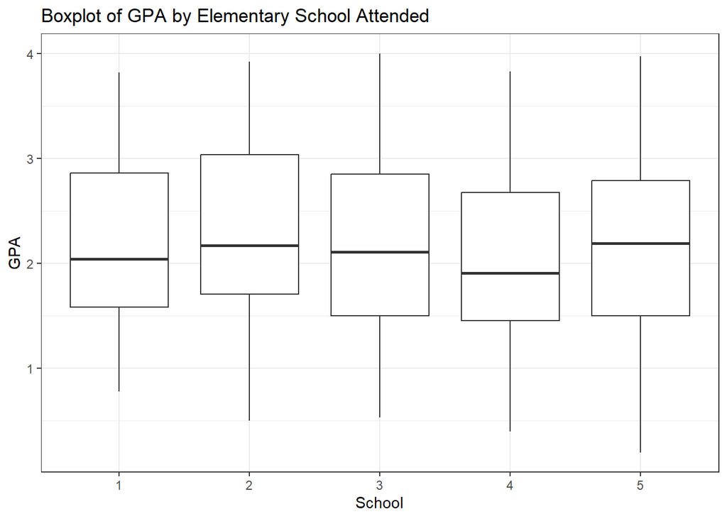

| School | Count |
| --- | --- |
| 1 | 27 |
| 2 | 48 |
| 3 | 69 |
| 4 | 68 |
| 5 | 75 |

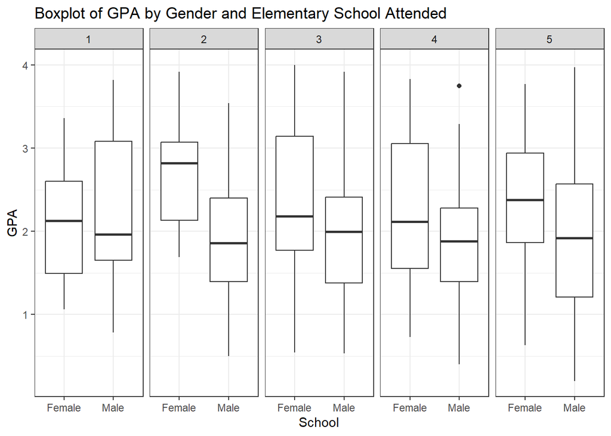

Gender by Elementary School Attended

|  | 1 | 2 | 3 | 4 | 5 |
| --- | --- | --- | --- | --- | --- |
| Female | 10 | 21 | 41 | 34 | 38 |
| Male | 17 | 27 | 28 | 34 | 37 |

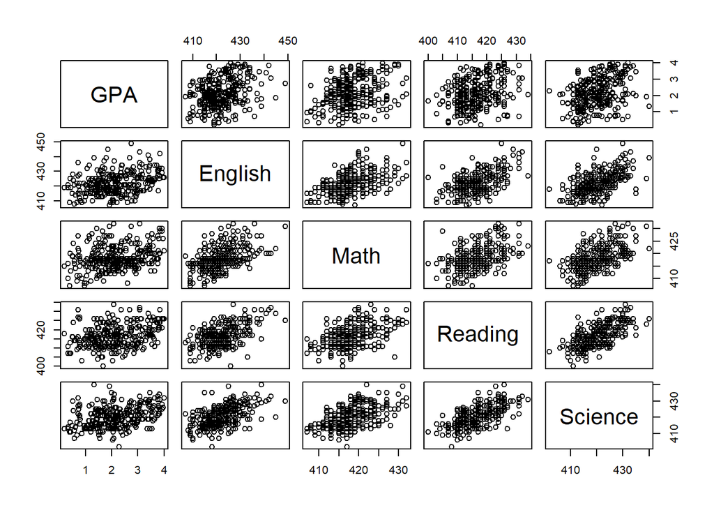